# ML-Classification-Imbalance

Bin Li

# 1 Data Preparation

```r
library(tidyverse)
#Combine two datasets
model.data.train = read.csv("/Volumes/LI/work_sample/model_data_train.csv")
count.both = read.csv("/Volumes/LI/work_sample/count_both.csv")
data.train = cbind(model.data.train, count.both[,3:4])

# Change feature types from char. to factor
data.train = data.train %>%
  mutate(feature1 = factor(feature1),
         feature2 = factor(feature2),
         feature3 = factor(feature3),
         stops = as.integer(stops),
         turns = as.integer(turns),
         y = factor(y)
         )
```

# 2 Explanatory Data Analysis

## 2.1 Check Major Numerical Variables and y

The plot below gives us a general insight about the numeric features. The lower left displays the distribution of them. The upper right is a correlation matrix. And the right side shows the boxplot of each numeric feature grouped by the response, y.  
Several problems are uncovered.  
(1) **Skewness**: “feature11”, “feature12”, and “feature13” have a wide range of values and they are extremely large, which would be a issue when a parametric model is fitted. “stops” also has a skewed distribution. Transformation and feature scaling are needed for parametric models.  
(2) **Multicollinearity**: The correlation matrix tells us several paris of features, (“feature5” and “feature6”, “feature8” and “feature14”, as well as “feature11” and “feature13”), are correlated heavily. Multicollinearity should be taken care of for some model.  
(3) **Imbalanced data**: The bar chart for y in the right corner indicates the dataset is imbalanced. The ratio of counts between “y = 0” and “y = 1” is not near 0.5. Some thechniques should be considered to determine an optimal threshold and make model comparison.

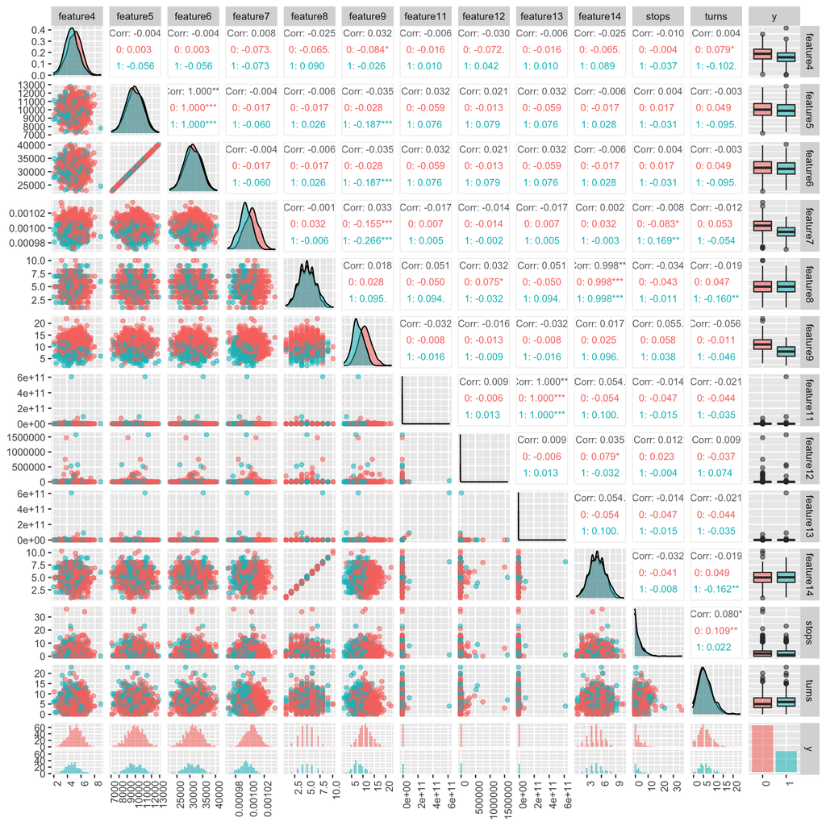

```r
num.data = data.train[, c(5:10, 12:15, 17, 18, 16)]
library(ggplot2)
library(GGally)
ggpairs(num.data, ggplot2::aes(colour = y, alpha = 0.1),
        axisLabels = "show", upper = list(continuous = wrap("cor",size = 3))) +
  theme(axis.text.x = element_text(angle = 90, hjust = 1))
```

## 2.2 Check Categorical Variables

(1) Feature1: Mosaic plot shows the proportion of “False” and “Ture” when y = 0 and y = 1 respectively. It’s clear that the proportion of “False” and “Ture” when y = 0 is not the same as that when y = 1. Therefore, “feature1” could have some association with y.

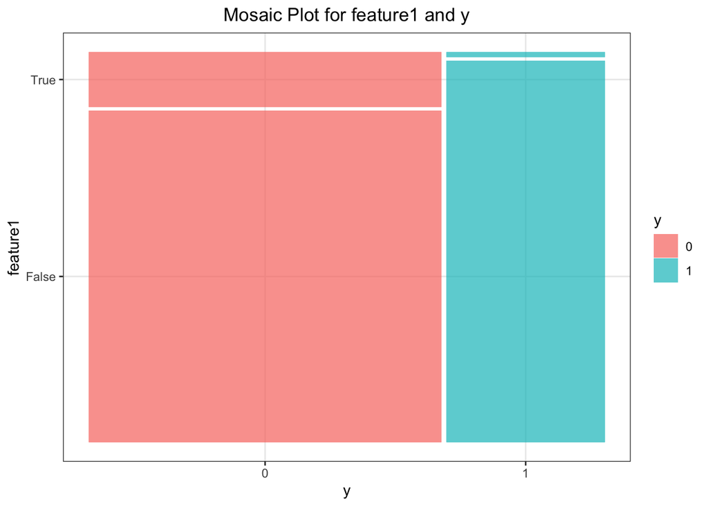

```r
#feature1
library(ggmosaic)
ggplot() +
  geom_mosaic(aes(x = product(feature1, y), fill = y), alpha = 0.7, data = data.train) +
  theme_bw() +
  labs(title = "Mosaic Plot for feature1 and y") +
  theme(plot.title = element_text(hjust = 0.5))
```

(2) Feature 2 and Feature 10: Both “feature2” and “feature10” have only one level, meaning they are non-informative features for the models.

```r
#feature2
unique(data.train$feature2)
```

```
## [1] False
## Levels: False
```

```r
unique(data.train$feature10)
```

```
## [1] 1
```

(3) Feature 3: The barplot provides some relation between “feature3” and “y”. When y = 0, “feature3 = False” has fewer counts than “True”. In contrary, “feature3 = False” has more counts than “True” when y = 1.

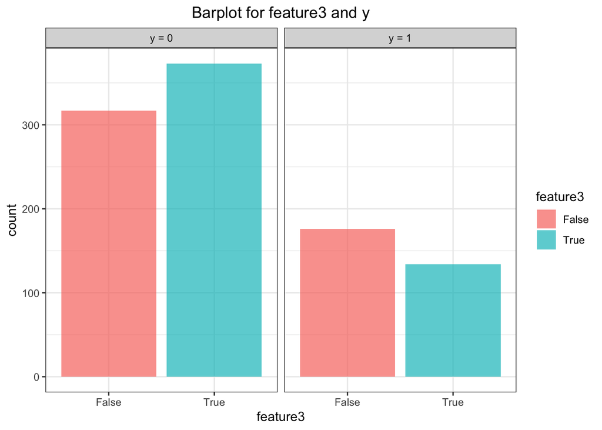

```r
#feature3
ggplot() +
  geom_bar(aes(feature3, fill = feature3), stat = "count", alpha = 0.7, data = data.train) +
  labs(title = "Barplot for feature3 and y") +
  theme_bw() +
  theme(plot.title = element_text(hjust = 0.5)) +
  facet_wrap(~y,
             labeller = labeller(y = c("0" = "y = 0", "1" = "y = 1")))
```

# 3 Modeling

## 3.1 Check Features and NAs

(1) **Check zero features**: “feature2” and “feature10” are zero features contributing no imformation to models. We can exclude them when fitting a model.  
(2) **Check NAs**: No missing values appears in the dataset.

```r
#Check zero or near zero features
library(caret)
nearZeroVar(data.train, saveMetrics = TRUE) %>%
  tibble::rownames_to_column() %>%
  filter(nzv)
```

```
##     rowname freqRatio percentUnique zeroVar  nzv
## 1  feature2         0           0.1    TRUE TRUE
## 2 feature10         0           0.1    TRUE TRUE
```

```r
#Check NAs
sum(is.na(data.train))
```

```
## [1] 0
```

## 3.2 Random Forest Model

Based on the explanatory data analysis, a model resistent to skewness and multicollinearity should be proposed. The nonparamatric model, random forest, could be a potential fit.  
(1) **Build RF model** : The data is split into training and test sets based a ratio 7 to 3 through stratified sampling. Grid search is conducted to find out the optimal value for each parameter. Then, the model, **rf.opt**, is built through “ranger” function. The variance importance plot shows “feature9”, “feature7”, and “feature4” are the top three important features.

```r
library(ranger)
library(rsample)
# Remove feature2 and feature10 in the model
rf.data = data.train[,c(-1,-3,-11)]
rf2.data = rf.data %>%
  mutate(y = factor(y, labels = make.names(levels(y))))

# Split into training and test sets
set.seed(1)
split.strat = initial_split(rf2.data, prop = 0.7, strata = "y")
rf.train = training(split.strat)
rf.test = testing(split.strat)


# Grid Search for optimal values
n.feature = ncol(rf.train) - 1

hyper.grid = expand.grid(
  mtry = floor(n.feature*c(0.3, 0.5, 0.6, 0.8)),
  min.node.size = c(1,3,5,8),
  replace = c(TRUE, FALSE),
  sample.fraction = c(0.5, 0.63, 0.7),
  num.trees = c(1000, 2000),
  OOB = NA
)


for(i in seq_len(nrow(hyper.grid))){
  rf.ranger = ranger(
    formula = y ~.,
    data = rf.train,
    num.trees = hyper.grid$num.trees[i],
    mtry = hyper.grid$mtry[i],
    importance = "impurity",
    min.node.size = hyper.grid$min.node.size[i],
    write.forest = FALSE,
    replace = hyper.grid$replace[i],
    sample.fraction = hyper.grid$sample.fraction[i],
    verbose = FALSE,
    seed = 1,
    probability = TRUE,
    respect.unordered.factors = "order"
  )
 hyper.grid$OOB[i] = rf.ranger$prediction.error

}

# Use OOB in ranger function to select the optimal values
hyper.grid %>% arrange(OOB) %>% head(10)
```

```
##    mtry min.node.size replace sample.fraction num.trees       OOB
## 1     7             1   FALSE            0.63      1000 0.1064175
## 2     7             5   FALSE            0.63      1000 0.1065282
## 3     7             5   FALSE            0.63      2000 0.1065943
## 4     7             3   FALSE            0.70      2000 0.1066182
## 5     7             1   FALSE            0.63      2000 0.1066691
## 6     7             3   FALSE            0.63      1000 0.1066749
## 7     4             5   FALSE            0.70      1000 0.1066789
## 8     7             5   FALSE            0.70      2000 0.1066900
## 9     7             3   FALSE            0.63      2000 0.1067083
## 10    7             1   FALSE            0.50      1000 0.1068342
```

```r
# Fit the random forest model with the optimal values
rf.opt = ranger(
    formula = y ~.,
    data = rf.train,
    num.trees = 2000,
    mtry = 7,
    importance = "impurity",
    min.node.size = 3,
    replace = FALSE,
    sample.fraction = 0.7,
    verbose = FALSE,
    seed = 1,
    respect.unordered.factors = "order",
    probability = TRUE
  )

# Print RF result
print(rf.opt)
```

```
## Ranger result
##
## Call:
##  ranger(formula = y ~ ., data = rf.train, num.trees = 2000, mtry = 7,      importance = "impurity", min.node.size = 3, replace = FALSE,      sample.fraction = 0.7, verbose = FALSE, seed = 1, respect.unordered.factors = "order",      probability = TRUE)
##
## Type:                             Probability estimation
## Number of trees:                  2000
## Sample size:                      699
## Number of independent variables:  14
## Mtry:                             7
## Target node size:                 3
## Variable importance mode:         impurity
## Splitrule:                        gini
## OOB prediction error (Brier s.):  0.1066182
```

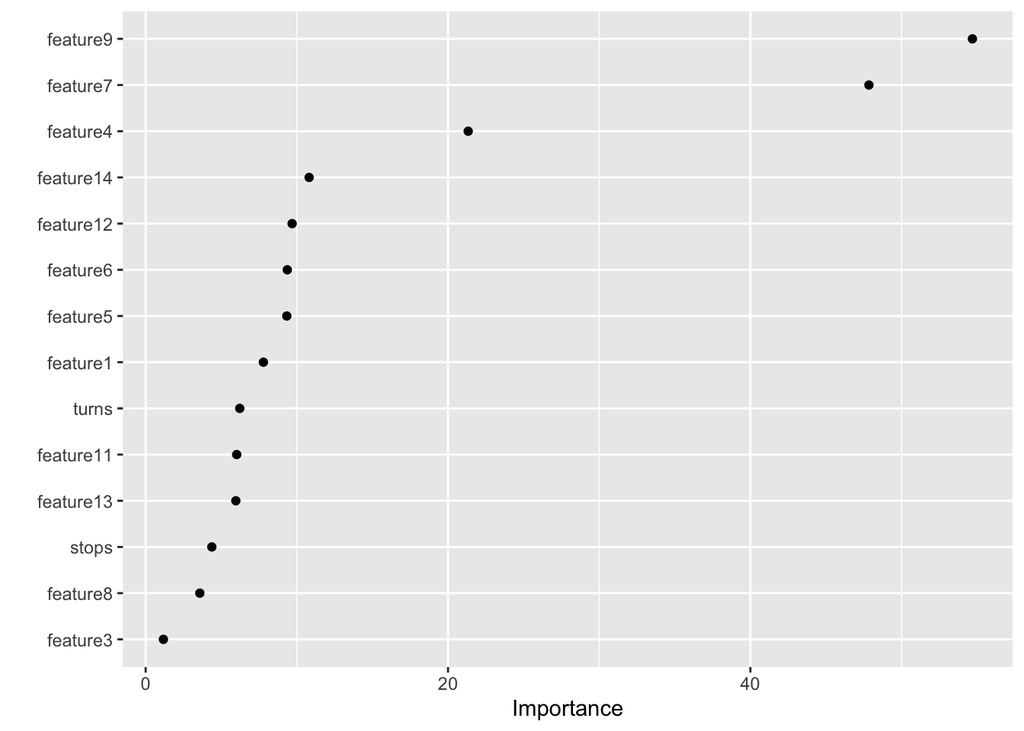

```r
library(vip)
# Variable Importance Plot for RF model
vip(rf.opt, 14, geom = "point")
```

(2) **Test RF model**: The random forest model is applied to the test set. ROC values are calculated. Since the data is imbalanced, the threshold should be determined via “coords” function. It’s not plausible to use 0.5 as the probability threshold to make the calssification. After the optimal threshold is figured out, a confusion matrix is generated. Sensitivity(recall), specificity, precision, F1 score, as well as accuracy are calculated.

```r
library(pROC)
# Test RF model with the test set
rf.test.yhat = predict(rf.opt, rf.test)
rf.test.roc = roc(rf.test$y, rf.test.yhat$prediction[,2])
# find optimal threshold
rf.opt.th = coords(rf.test.roc, x = "best", best.method = "closest.topleft", transpose = TRUE)
rf.opt.th
```

```
##   threshold specificity sensitivity
##   0.2850833   0.7788462   0.8387097
```

```r
# creat confusion matrix
rf.test.yhat = as.data.frame(rf.test.yhat$predictions) %>%
  mutate(yhat = ifelse(X1 > rf.opt.th[1], 1, 0))

rf.cm = table(rf.test.yhat$yhat, rf.test$y, dnn = c("pred", "true"))
rf.cm
```

```
##     true
## pred  X0  X1
##    0 162  15
##    1  46  78
```

```r
# sensitivity(recall), specificity, precision, F1 score, accuracy
rf.sensitivity = round(rf.cm[4]/(rf.cm[4] + rf.cm[3]),4)
rf.specificity = round(rf.cm[1]/(rf.cm[1] + rf.cm[2]),4)
rf.precision = round(rf.cm[4]/(rf.cm[4] + rf.cm[2]),4)
rf.f1 = round(2*rf.precision*rf.sensitivity/(rf.precision + rf.sensitivity),4)
rf.accuracy = round((rf.cm[1] + rf.cm[4])/sum(rf.cm),4)

cbind(rf.sensitivity, rf.specificity, rf.precision, rf.f1, rf.accuracy)
```

```
##      rf.sensitivity rf.specificity rf.precision  rf.f1 rf.accuracy
## [1,]         0.8387         0.7788        0.629 0.7189      0.7973
```

## 3.3 Logistic Regression with Elastic Net Regularization

(1) **Build LR model**: Logisic regression is a classic model for classification. Since there are multicolliearity issue, a penalized logistic regression model can be considered. Elastic net regularization has the feature of ridge penalty to deal with multicollinearity as well as that of lasso penalty to take care of variable selection.  
Log transformation is conducted on skewed features. And alpha and lambda are found through grid search. After feature scaling, a regularized logistic regression model is fitted and named as **lr.fit**. The top four features are “feature9”, “feature7”, “feature1”, and “feature4”.

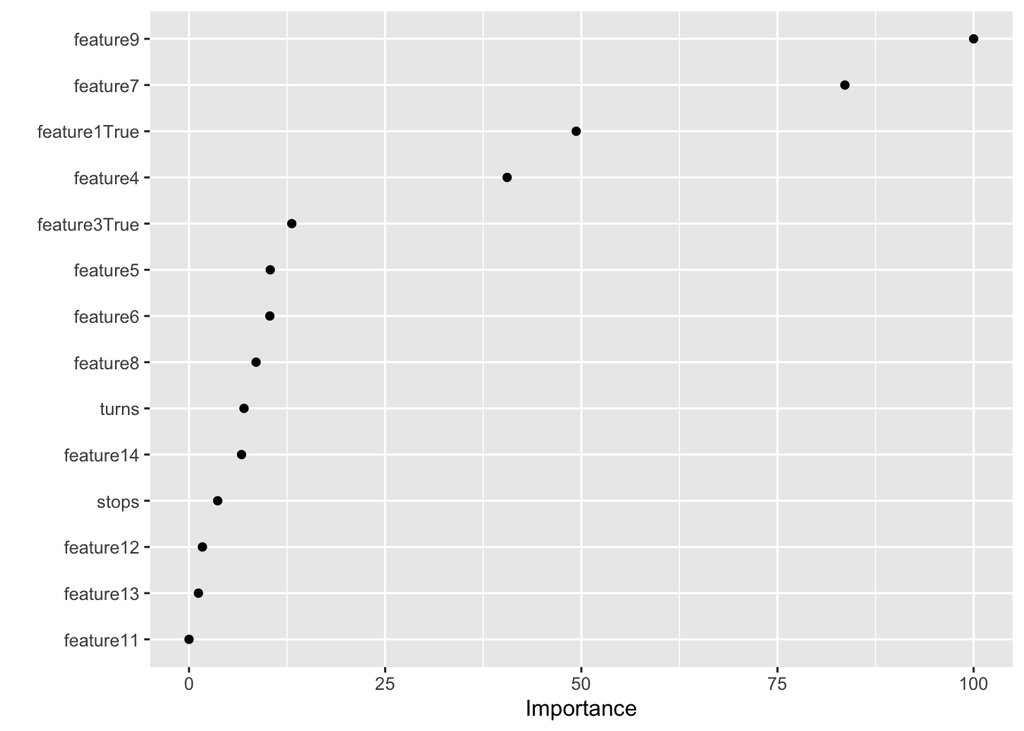

```r
library(glmnet)
#Data preparation for LR model
lr.train = rf.train %>%
  mutate(feature11 = log(feature11),
         feature12 = log(feature12),
         feature13 = log(feature13),
         stops = log(stops + 0.01))

lr.test = rf.test %>%
  mutate(feature11 = log(feature11),
         feature12 = log(feature12),
         feature13 = log(feature13),
         stops = log(stops + 0.01))

#Grid search for parameters
lr.ctrl = trainControl(method = "cv", number = 10)

set.seed(1)
lr.fit = train(y~.,
               data = lr.train,
               method = "glmnet",
               trControl = lr.ctrl,
               preProcess = c("center", "scale"),
               tuneGrid = data.frame(alpha = seq(0, 0.1, 0.001),
                                     lambda = seq(0, 0.1, 0.001)))

# Variable Importance Plot for LR model
vip(lr.fit, 20, geom = "point")
```

(2) **Test LR model**: Test set is used to test the performance of LR model with penalty. The optimal threshold is found in the same fashion as random forest model. Then a confusion matrix and values are obtained.

```r
# test model
lr.test.yhat = predict(lr.fit, lr.test, type = "prob")
# get ROC
lr.test.roc = roc(lr.test$y, lr.test.yhat[,2])
# find optimal threshold
lr.opt.th = coords(lr.test.roc, x = "best", best.method = "closest.topleft", transpose = TRUE)
lr.opt.th
```

```
##   threshold specificity sensitivity
##   0.3735101   0.8365385   0.8602151
```

```r
# creat confusion matrix
lr.test.yhat = as.data.frame(lr.test.yhat) %>%
  mutate(yhat = ifelse(X1 > lr.opt.th[1], 1, 0))

lr.cm = table(lr.test.yhat$yhat, lr.test$y, dnn = c("pred", "true"))
lr.cm
```

```
##     true
## pred  X0  X1
##    0 174  13
##    1  34  80
```

```r
# sensitivity(recall), specificity, precision, F1 score, accuracy
lr.sensitivity = round(lr.cm[4]/(lr.cm[4] + lr.cm[3]),4)
lr.specificity= round(lr.cm[1]/(lr.cm[1] + lr.cm[2]),4)
lr.precision = round(lr.cm[4]/(lr.cm[4] + lr.cm[2]),4)
lr.f1 = round(2*lr.precision*lr.sensitivity/(lr.precision + lr.sensitivity),4)
lr.accuracy = round((lr.cm[1] + lr.cm[4])/sum(lr.cm),4)

cbind(lr.sensitivity, lr.specificity, lr.precision, lr.f1, lr.accuracy)
```

```
##      lr.sensitivity lr.specificity lr.precision lr.f1 lr.accuracy
## [1,]         0.8602         0.8365       0.7018 0.773      0.8439
```

# 4 Model Comparison and Selection

```r
# ROC curve and AUC
par(pty = "s")
roc(rf.test$y, rf.test.yhat[,2], legacy.axes = TRUE,
    plot = TRUE, col = 2, lwd = 2, print.auc = TRUE)
```

```
##
## Call:
## roc.default(response = rf.test$y, predictor = rf.test.yhat[,     2], plot = TRUE, legacy.axes = TRUE, col = 2, lwd = 2, print.auc = TRUE)
##
## Data: rf.test.yhat[, 2] in 208 controls (rf.test$y X0) < 93 cases (rf.test$y X1).
## Area under the curve: 0.8924
```

```r
roc(lr.test$y, lr.test.yhat[,2], legacy.axes = TRUE,
    plot = TRUE, col = 4, lwd = 2, print.auc = TRUE, print.auc.y = 0.35, add = TRUE)
```

```
##
## Call:
## roc.default(response = lr.test$y, predictor = lr.test.yhat[,     2], plot = TRUE, legacy.axes = TRUE, col = 4, lwd = 2, print.auc = TRUE,     print.auc.y = 0.35, add = TRUE)
##
## Data: lr.test.yhat[, 2] in 208 controls (lr.test$y X0) < 93 cases (lr.test$y X1).
## Area under the curve: 0.9093
```

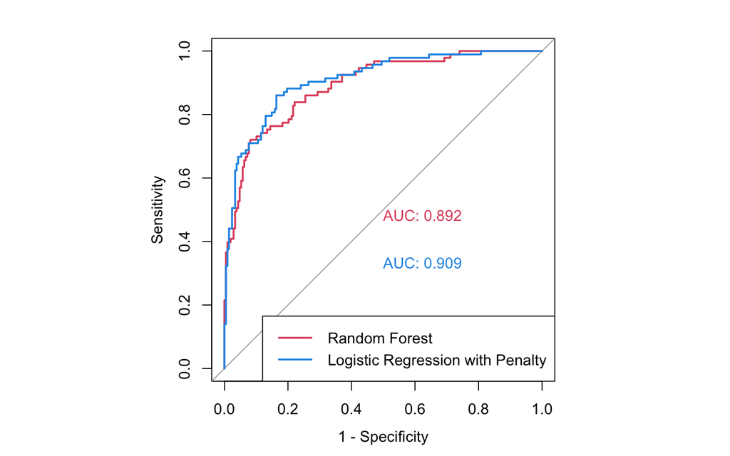

```r
legend("bottomright", legend = c("Random Forest", "Logistic Regression with Penalty"), col = c(2, 4), lwd= 2)
```

```r
# results
compare = matrix(c(0.8602, 0.8792, 0.7619, 0.8081, 0.8733, 0.8602, 0.8986, 0.7921, 0.8247, 0.8867),
               nrow = 2, byrow = TRUE)
colnames(compare) = c("Sensitivity", "Specificity", "Precision", "F1 Score", "Accuracy")
rownames(compare) = c("RF", "LR with P")

compare
```

[output not shown]

# 5 Discussion

(1) “feature8” has 10 levels from 1 to 10. It’s better to treat it as a categorical variable in a model. But, there would be too many features in LR with penalty model if “feature8” is treated as categorical variable. To keep the data consistency for the two models, “feature8” is just what it is.  
(2) Since the data is imbalanced, accuracy is not the first choice to compare model performance. Sensitivity, specificity or precision can be used as the criteria.

# 6 Prediction for the Test Set

## 6.1 Read trip_data_test.zip and Count Stops and Turns

The number of stops and turns are calcualted using functions “count.stop” and “count.turn2”, and then they are combined with “work_sample_test_trips” dataset.

```r
# Read work_sample_test_set

model.data.test = read.csv("/Volumes/LI/work_sample/model_data_test.csv")
test.count.both = read.csv("/Volumes/LI/work_sample/test_count_both.csv")

data.test = cbind(model.data.test, test.count.both[,3:4])

#Check data.test
head(data.test,3)
```

```
##   filename feature1 feature2 feature3 feature4  feature5 feature6     feature7
## 1 1000.csv    False    False     True 6.002290 11021.870 34626.23 0.0009863145
## 2 1001.csv    False    False     True 5.886440 11983.808 37648.24 0.0009967980
## 3 1002.csv     True    False     True 5.465596  8028.071 25220.93 0.0009849330
##   feature8 feature9 feature10    feature11    feature12    feature13 feature14
## 1        5        9         1 1.954513e+02     22.26906 2.014536e+02  5.076019
## 2        5       18         1 9.078651e+04     45.62655 9.079240e+04  5.105855
## 3        6       15         1 6.150144e+07 501316.50696 6.150145e+07  5.925519
##   stops turns
## 1     7    13
## 2     1     4
## 3     2     9
```

## 6.2 Predict with Random Forest Model

(1) **Data Preparation**: The same as training set, “feature2” and “feature10” are non-informative features. No missing values is in the test set for prediction.

```r
#Check zero or near zero features
nearZeroVar(data.test, saveMetrics = TRUE) %>%
  tibble::rownames_to_column() %>%
  filter(nzv)
```

```
##     rowname freqRatio percentUnique zeroVar  nzv
## 1  feature2       875     0.2283105   FALSE TRUE
## 2 feature10         0     0.1141553    TRUE TRUE
```

```r
#Check NAs
sum(is.na(data.test))
```

```
## [1] 0
```

```r
# Change feature types from char. to factor
data.test = data.test %>%
  mutate(feature1 = factor(feature1),
         feature2 = factor(feature2),
         feature3 = factor(feature3),
         stops = as.integer(stops),
         turns = as.integer(turns)) %>%
  select(-filename, -feature2, -feature10)
```

(2) **Prediction**: Random forest model, **rf.opt**, is used to predict y for the test set. The classification decision is based on the optimal threshold obtained from ROC. Finally, the prediction result with filename is saved as a csv file, **test_prediction**.

```r
# Predict
pred.test = predict(rf.opt, data.test)
# Classify with optimal threshold
pred.test = as.data.frame(pred.test$predictions) %>%
  mutate(prediction = ifelse(X1 > rf.opt.th[1], 1, 0))

# Save as a csv
test.prediction = as.data.frame(cbind(model.data.test$filename, pred.test$prediction))
colnames(test.prediction) = c("filename", "prediction")
head(test.prediction)
```

```
##   filename prediction
## 1 1000.csv          1
## 2 1001.csv          0
## 3 1002.csv          0
## 4 1003.csv          1
## 5 1004.csv          1
## 6 1005.csv          0
```